# Klasifikasi Parkinsons’s Disease dengan Metode Naive Bayes

Aldias Irvan Nugraha - 221810138 - 3SD1

12/2/2020

# 1. Proses

### Load Library

Tiga library yang dibutuhkan, yaitu **naivebayes, psych, dan caret**. Library **naivebayes** akan digunakan untuk membuat modelnya. Library **psych** akan digunakan untuk melihat korelasi antar variabel. Library **caret** digunakan untuk membuat confusion matriks dan melihar akurasi model.

```r
library(naivebayes)
library(psych)
library(caret)
```

### Import dataset

```r
dt <- read.table("https://archive.ics.uci.edu/ml/machine-learning-databases/parkinsons/parkinsons.data", sep = ",", header = TRUE)
head(dt) #tampilkan 5 data
```

```
##             name MDVP.Fo.Hz. MDVP.Fhi.Hz. MDVP.Flo.Hz. MDVP.Jitter...
## 1 phon_R01_S01_1     119.992      157.302       74.997        0.00784
## 2 phon_R01_S01_2     122.400      148.650      113.819        0.00968
## 3 phon_R01_S01_3     116.682      131.111      111.555        0.01050
## 4 phon_R01_S01_4     116.676      137.871      111.366        0.00997
## 5 phon_R01_S01_5     116.014      141.781      110.655        0.01284
## 6 phon_R01_S01_6     120.552      131.162      113.787        0.00968
##   MDVP.Jitter.Abs. MDVP.RAP MDVP.PPQ Jitter.DDP MDVP.Shimmer MDVP.Shimmer.dB.
## 1          0.00007  0.00370  0.00554    0.01109      0.04374            0.426
## 2          0.00008  0.00465  0.00696    0.01394      0.06134            0.626
## 3          0.00009  0.00544  0.00781    0.01633      0.05233            0.482
## 4          0.00009  0.00502  0.00698    0.01505      0.05492            0.517
## 5          0.00011  0.00655  0.00908    0.01966      0.06425            0.584
## 6          0.00008  0.00463  0.00750    0.01388      0.04701            0.456
##   Shimmer.APQ3 Shimmer.APQ5 MDVP.APQ Shimmer.DDA     NHR    HNR status     RPDE
## 1      0.02182      0.03130  0.02971     0.06545 0.02211 21.033      1 0.414783
## 2      0.03134      0.04518  0.04368     0.09403 0.01929 19.085      1 0.458359
## 3      0.02757      0.03858  0.03590     0.08270 0.01309 20.651      1 0.429895
## 4      0.02924      0.04005  0.03772     0.08771 0.01353 20.644      1 0.434969
## 5      0.03490      0.04825  0.04465     0.10470 0.01767 19.649      1 0.417356
## 6      0.02328      0.03526  0.03243     0.06985 0.01222 21.378      1 0.415564
##        DFA   spread1  spread2       D2      PPE
## 1 0.815285 -4.813031 0.266482 2.301442 0.284654
## 2 0.819521 -4.075192 0.335590 2.486855 0.368674
## 3 0.825288 -4.443179 0.311173 2.342259 0.332634
## 4 0.819235 -4.117501 0.334147 2.405554 0.368975
## 5 0.823484 -3.747787 0.234513 2.332180 0.410335
## 6 0.825069 -4.242867 0.299111 2.187560 0.357775
```

*Sekilas mengenai dataset:*

Title: Parkinsons Disease Data Set

Abstract: Oxford Parkinson’s Disease Detection Dataset

Source:

The dataset was created by Max Little of the University of Oxford, in collaboration with the National Centre for Voice and Speech, Denver, Colorado, who recorded the speech signals. The original study published the feature extraction methods for general voice disorders.

Data Set Information:

This dataset is composed of a range of biomedical voice measurements from 31 people, 23 with Parkinson’s disease (PD). Each column in the table is a particular voice measure, and each row corresponds one of 195 voice recording from these individuals (“name” column). The main aim of the data is to discriminate healthy people from those with PD, according to “status” column which is set to 0 for healthy and 1 for PD.

The data is in ASCII CSV format. The rows of the CSV file contain an instance corresponding to one voice recording. There are around six recordings per patient, the name of the patient is identified in the first column.

Attribute Information:

Matrix column entries (attributes):

- name - ASCII subject name and recording number
- MDVP:Fo(Hz) - Average vocal fundamental frequency
- MDVP:Fhi(Hz) - Maximum vocal fundamental frequency
- MDVP:Flo(Hz) - Minimum vocal fundamental frequency
- MDVP:Jitter(%),MDVP:Jitter(Abs),MDVP:RAP,MDVP:PPQ,Jitter:DDP - Several
- measures of variation in fundamental frequency
- MDVP:Shimmer,MDVP:Shimmer(dB),Shimmer:APQ3,Shimmer:APQ5,MDVP:APQ,Shimmer:DDA - Several measures of variation in amplitude
- NHR,HNR - Two measures of ratio of noise to tonal components in the voice
- status - Health status of the subject (one) - Parkinson’s, (zero) - healthy
- RPDE,D2 - Two nonlinear dynamical complexity measures
- DFA - Signal fractal scaling exponent
- spread1,spread2,PPE - Three nonlinear measures of fundamental frequency variation

### Cek Data

```r
str(dt) #tipe data
```

```
## 'data.frame':    195 obs. of  24 variables:
##  $ name            : Factor w/ 195 levels "phon_R01_S01_1",..: 1 2 3 4 5 6 7 8 9 10 ...
##  $ MDVP.Fo.Hz.     : num  120 122 117 117 116 ...
##  $ MDVP.Fhi.Hz.    : num  157 149 131 138 142 ...
##  $ MDVP.Flo.Hz.    : num  75 114 112 111 111 ...
##  $ MDVP.Jitter...  : num  0.00784 0.00968 0.0105 0.00997 0.01284 ...
##  $ MDVP.Jitter.Abs.: num  0.00007 0.00008 0.00009 0.00009 0.00011 0.00008 0.00003 0.00003 0.00006 0.00006 ...
##  $ MDVP.RAP        : num  0.0037 0.00465 0.00544 0.00502 0.00655 0.00463 0.00155 0.00144 0.00293 0.00268 ...
##  $ MDVP.PPQ        : num  0.00554 0.00696 0.00781 0.00698 0.00908 0.0075 0.00202 0.00182 0.00332 0.00332 ...
##  $ Jitter.DDP      : num  0.0111 0.0139 0.0163 0.015 0.0197 ...
##  $ MDVP.Shimmer    : num  0.0437 0.0613 0.0523 0.0549 0.0643 ...
##  $ MDVP.Shimmer.dB.: num  0.426 0.626 0.482 0.517 0.584 0.456 0.14 0.134 0.191 0.255 ...
##  $ Shimmer.APQ3    : num  0.0218 0.0313 0.0276 0.0292 0.0349 ...
##  $ Shimmer.APQ5    : num  0.0313 0.0452 0.0386 0.0401 0.0483 ...
##  $ MDVP.APQ        : num  0.0297 0.0437 0.0359 0.0377 0.0447 ...
##  $ Shimmer.DDA     : num  0.0654 0.094 0.0827 0.0877 0.1047 ...
##  $ NHR             : num  0.0221 0.0193 0.0131 0.0135 0.0177 ...
##  $ HNR             : num  21 19.1 20.7 20.6 19.6 ...
##  $ status          : int  1 1 1 1 1 1 1 1 1 1 ...
##  $ RPDE            : num  0.415 0.458 0.43 0.435 0.417 ...
##  $ DFA             : num  0.815 0.82 0.825 0.819 0.823 ...
##  $ spread1         : num  -4.81 -4.08 -4.44 -4.12 -3.75 ...
##  $ spread2         : num  0.266 0.336 0.311 0.334 0.235 ...
##  $ D2              : num  2.3 2.49 2.34 2.41 2.33 ...
##  $ PPE             : num  0.285 0.369 0.333 0.369 0.41 ...
```

```r
summary(dt) #ringkasan data
```

```
##              name      MDVP.Fo.Hz.      MDVP.Fhi.Hz.    MDVP.Flo.Hz.
##  phon_R01_S01_1:  1   Min.   : 88.33   Min.   :102.1   Min.   : 65.48
##  phon_R01_S01_2:  1   1st Qu.:117.57   1st Qu.:134.9   1st Qu.: 84.29
##  phon_R01_S01_3:  1   Median :148.79   Median :175.8   Median :104.31
##  phon_R01_S01_4:  1   Mean   :154.23   Mean   :197.1   Mean   :116.32
##  phon_R01_S01_5:  1   3rd Qu.:182.77   3rd Qu.:224.2   3rd Qu.:140.02
##  phon_R01_S01_6:  1   Max.   :260.11   Max.   :592.0   Max.   :239.17
##  (Other)       :189
##  MDVP.Jitter...     MDVP.Jitter.Abs.       MDVP.RAP           MDVP.PPQ
##  Min.   :0.001680   Min.   :7.000e-06   Min.   :0.000680   Min.   :0.000920
##  1st Qu.:0.003460   1st Qu.:2.000e-05   1st Qu.:0.001660   1st Qu.:0.001860
##  Median :0.004940   Median :3.000e-05   Median :0.002500   Median :0.002690
##  Mean   :0.006220   Mean   :4.396e-05   Mean   :0.003306   Mean   :0.003446
##  3rd Qu.:0.007365   3rd Qu.:6.000e-05   3rd Qu.:0.003835   3rd Qu.:0.003955
##  Max.   :0.033160   Max.   :2.600e-04   Max.   :0.021440   Max.   :0.019580
##
##    Jitter.DDP        MDVP.Shimmer     MDVP.Shimmer.dB.  Shimmer.APQ3
##  Min.   :0.002040   Min.   :0.00954   Min.   :0.0850   Min.   :0.004550
##  1st Qu.:0.004985   1st Qu.:0.01650   1st Qu.:0.1485   1st Qu.:0.008245
##  Median :0.007490   Median :0.02297   Median :0.2210   Median :0.012790
##  Mean   :0.009920   Mean   :0.02971   Mean   :0.2823   Mean   :0.015664
##  3rd Qu.:0.011505   3rd Qu.:0.03789   3rd Qu.:0.3500   3rd Qu.:0.020265
##  Max.   :0.064330   Max.   :0.11908   Max.   :1.3020   Max.   :0.056470
##
##   Shimmer.APQ5        MDVP.APQ        Shimmer.DDA           NHR
##  Min.   :0.00570   Min.   :0.00719   Min.   :0.01364   Min.   :0.000650
##  1st Qu.:0.00958   1st Qu.:0.01308   1st Qu.:0.02474   1st Qu.:0.005925
##  Median :0.01347   Median :0.01826   Median :0.03836   Median :0.011660
##  Mean   :0.01788   Mean   :0.02408   Mean   :0.04699   Mean   :0.024847
##  3rd Qu.:0.02238   3rd Qu.:0.02940   3rd Qu.:0.06080   3rd Qu.:0.025640
##  Max.   :0.07940   Max.   :0.13778   Max.   :0.16942   Max.   :0.314820
##
##       HNR             status            RPDE             DFA
##  Min.   : 8.441   Min.   :0.0000   Min.   :0.2566   Min.   :0.5743
##  1st Qu.:19.198   1st Qu.:1.0000   1st Qu.:0.4213   1st Qu.:0.6748
##  Median :22.085   Median :1.0000   Median :0.4960   Median :0.7223
##  Mean   :21.886   Mean   :0.7538   Mean   :0.4985   Mean   :0.7181
##  3rd Qu.:25.076   3rd Qu.:1.0000   3rd Qu.:0.5876   3rd Qu.:0.7619
##  Max.   :33.047   Max.   :1.0000   Max.   :0.6852   Max.   :0.8253
##
##     spread1          spread2               D2             PPE
##  Min.   :-7.965   Min.   :0.006274   Min.   :1.423   Min.   :0.04454
##  1st Qu.:-6.450   1st Qu.:0.174350   1st Qu.:2.099   1st Qu.:0.13745
##  Median :-5.721   Median :0.218885   Median :2.362   Median :0.19405
##  Mean   :-5.684   Mean   :0.226510   Mean   :2.382   Mean   :0.20655
##  3rd Qu.:-5.046   3rd Qu.:0.279234   3rd Qu.:2.636   3rd Qu.:0.25298
##  Max.   :-2.434   Max.   :0.450493   Max.   :3.671   Max.   :0.52737
##
```

### Preprocessing

*Mengecek multikolinearitas dengan korelasi spearman*

Melihat korelasi dari tiap variabel, bila terdapat korelasi yang tinggi, hilangkan salah satu variabel.

```r
kor <-as.dist(round(cor(dt[,2:24],method = "spearman"),2))
kor
```

```
##                  MDVP.Fo.Hz. MDVP.Fhi.Hz. MDVP.Flo.Hz. MDVP.Jitter...
## MDVP.Fhi.Hz.            0.80
## MDVP.Flo.Hz.            0.32         0.10
## MDVP.Jitter...         -0.27        -0.10        -0.41
## MDVP.Jitter.Abs.       -0.57        -0.36        -0.41           0.92
## MDVP.RAP               -0.20        -0.07        -0.36           0.96
## MDVP.PPQ               -0.30        -0.12        -0.38           0.97
## Jitter.DDP             -0.20        -0.07        -0.36           0.96
## MDVP.Shimmer           -0.16        -0.09        -0.25           0.73
## MDVP.Shimmer.dB.       -0.17        -0.06        -0.28           0.76
## Shimmer.APQ3           -0.14        -0.09        -0.21           0.70
## Shimmer.APQ5           -0.13        -0.06        -0.22           0.69
## MDVP.APQ               -0.23        -0.12        -0.31           0.73
## Shimmer.DDA            -0.14        -0.09        -0.21           0.70
## NHR                    -0.11         0.06        -0.46           0.80
## HNR                     0.06        -0.02         0.26          -0.73
## status                 -0.30        -0.26        -0.29           0.41
## RPDE                   -0.37        -0.22        -0.35           0.48
## DFA                    -0.42        -0.46         0.12           0.21
## spread1                -0.43        -0.26        -0.35           0.77
## spread2                -0.23        -0.12        -0.14           0.46
## D2                      0.25         0.26        -0.13           0.37
## PPE                    -0.43        -0.26        -0.35           0.77
##                  MDVP.Jitter.Abs. MDVP.RAP MDVP.PPQ Jitter.DDP MDVP.Shimmer
## MDVP.Fhi.Hz.
## MDVP.Flo.Hz.
## MDVP.Jitter...
## MDVP.Jitter.Abs.
## MDVP.RAP                     0.86
## MDVP.PPQ                     0.91     0.97
## Jitter.DDP                   0.86     1.00     0.97
## MDVP.Shimmer                 0.66     0.74     0.76       0.74
## MDVP.Shimmer.dB.             0.69     0.77     0.79       0.77         0.99
## Shimmer.APQ3                 0.63     0.72     0.73       0.72         0.99
## Shimmer.APQ5                 0.62     0.73     0.75       0.73         0.99
## MDVP.APQ                     0.69     0.72     0.76       0.72         0.97
## Shimmer.DDA                  0.63     0.72     0.73       0.72         0.99
## NHR                          0.70     0.80     0.78       0.80         0.77
## HNR                         -0.62    -0.75    -0.77      -0.75        -0.87
## status                       0.44     0.41     0.43       0.41         0.42
```

[output cut: 60 more lines]

```
## MDVP.Shimmer
## MDVP.Shimmer.dB.
## Shimmer.APQ3
## Shimmer.APQ5
## MDVP.APQ
## Shimmer.DDA
## NHR
## HNR
## status
## RPDE
## DFA
## spread1
## spread2
## D2
## PPE               0.41
```

Hasil nya didapatkan bahwa terdapat bebrapa variabel yang memiliki korelasi tinggi yaitu diatas 80%. Solusinya adalah menghilangkan salah satu dari dua variabel terkait. Berikut adalah daftar variable yang akan dihilangkan: * MDVP.Fhi.Hz. * MDVP.Jitter.Abs. * MDVP.RAP * MDVP.PPQ * Jitter.DDP * MDVP.Shimmer.dB. * Shimmer.APQ3 * Shimmer.APQ5 * MDVP.APQ * Shimmer.DDA * NHR * HNR * PPE

```r
dt <- dt[,-c(1,3,6:9,11:17,24)] #menghilangkan variabel di atas
str(dt)
```

```
## 'data.frame':    195 obs. of  10 variables:
##  $ MDVP.Fo.Hz.   : num  120 122 117 117 116 ...
##  $ MDVP.Flo.Hz.  : num  75 114 112 111 111 ...
##  $ MDVP.Jitter...: num  0.00784 0.00968 0.0105 0.00997 0.01284 ...
##  $ MDVP.Shimmer  : num  0.0437 0.0613 0.0523 0.0549 0.0643 ...
##  $ status        : int  1 1 1 1 1 1 1 1 1 1 ...
##  $ RPDE          : num  0.415 0.458 0.43 0.435 0.417 ...
##  $ DFA           : num  0.815 0.82 0.825 0.819 0.823 ...
##  $ spread1       : num  -4.81 -4.08 -4.44 -4.12 -3.75 ...
##  $ spread2       : num  0.266 0.336 0.311 0.334 0.235 ...
##  $ D2            : num  2.3 2.49 2.34 2.41 2.33 ...
```

*Membuat interval dan konversi ke factor*

Bila data num langsung dikonversikan menjadi factor maka akan menghasilkan level yang sangat banyak. Maka dari itu diperlukan pembuatan interval pada data. Interval ini dibagi berdasarkan sebaran letaknya pada Q1, Q2, Q3 (rendah, sedang, tinggi, sangat tinggi).

```r
#Mengambil data yang akan dibuat interval
dtin <- dt[,-c(5)] #menghilangkan variabel status

#Membuat interval
p <- lapply(dtin, FUN = function(a){cut(a,breaks=c(min(a),quantile(a,0.25),quantile(a,0.50),quantile(a,0.75),max(a)),labels = c("rendah","sedang","tinggi","sangat-tinggi"))})

#Merubah list ke data frame dan menggabungkan dengan status
dtfix <- data.frame(p[1:9],as.factor(dt$status))
levels(dtfix$as.factor.dt.status.) = c("Sehat","Parkinson") #merubah levels status menjadi sehat dan parkinson
colnames(dtfix)[10] <- "Status" #ubah nama variabel status
str(dtfix)
```

```
## 'data.frame':    195 obs. of  10 variables:
##  $ MDVP.Fo.Hz.   : Factor w/ 4 levels "rendah","sedang",..: 2 2 1 1 1 2 2 1 1 1 ...
##  $ MDVP.Flo.Hz.  : Factor w/ 4 levels "rendah","sedang",..: 1 3 3 3 3 3 3 2 2 2 ...
##  $ MDVP.Jitter...: Factor w/ 4 levels "rendah","sedang",..: 4 4 4 4 4 4 1 1 3 3 ...
##  $ MDVP.Shimmer  : Factor w/ 4 levels "rendah","sedang",..: 4 4 4 4 4 4 1 1 2 3 ...
##  $ RPDE          : Factor w/ 4 levels "rendah","sedang",..: 1 2 2 2 1 1 4 4 4 3 ...
##  $ DFA           : Factor w/ 4 levels "rendah","sedang",..: 4 4 4 4 4 4 4 4 4 4 ...
##  $ spread1       : Factor w/ 4 levels "rendah","sedang",..: 4 4 4 4 4 4 3 2 3 4 ...
##  $ spread2       : Factor w/ 4 levels "rendah","sedang",..: 3 4 4 4 3 4 3 2 4 4 ...
##  $ D2            : Factor w/ 4 levels "rendah","sedang",..: 2 3 2 3 2 2 1 1 2 3 ...
##  $ Status        : Factor w/ 2 levels "Sehat","Parkinson": 2 2 2 2 2 2 2 2 2 2 ...
```

*Mengecek multikolinearitas kembali dengan pairs.panels*

Memastikan bahwa tidak terdapat horelasi yang tinggi.

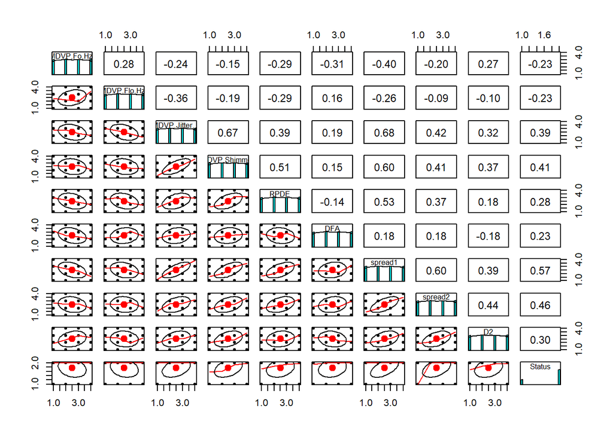

```r
pairs.panels(dtfix)
```

### Memisahkan data training dan data test

Memecah data menjadi data training(80% dari data awal) dan data test (20% dari data awal)

```r
set.seed(911)
sampel <- sample(2, nrow(dtfix), replace = T, prob = c(0.8,0.2))
trainingdat <- dtfix[sampel==1, ]
testingdat <- dtfix[sampel==2, ]
print(paste("Jumlah Train Data: ", nrow(trainingdat), "| Jumlah Test Data: ", nrow(testingdat)))
```

```
## [1] "Jumlah Train Data:  158 | Jumlah Test Data:  37"
```

### Membuat Model

```r
modelnaiv <- naive_bayes(Status~.,data=trainingdat)
modelnaiv
```

```
##
## ================================== Naive Bayes ==================================
##
##  Call:
## naive_bayes.formula(formula = Status ~ ., data = trainingdat)
##
## ---------------------------------------------------------------------------------
##
## Laplace smoothing: 0
##
## ---------------------------------------------------------------------------------
##
##  A priori probabilities:
##
##     Sehat Parkinson
## 0.2594937 0.7405063
##
## ---------------------------------------------------------------------------------
##
##  Tables:
##
## ---------------------------------------------------------------------------------
##  ::: MDVP.Fo.Hz. (Categorical)
## ---------------------------------------------------------------------------------
##
## MDVP.Fo.Hz.          Sehat  Parkinson
##   rendah        0.26829268 0.24786325
##   sedang        0.12195122 0.31623932
##   tinggi        0.04878049 0.28205128
##   sangat-tinggi 0.56097561 0.15384615
##
## ---------------------------------------------------------------------------------
##  ::: MDVP.Flo.Hz. (Categorical)
## ---------------------------------------------------------------------------------
##
## MDVP.Flo.Hz.         Sehat  Parkinson
##   rendah        0.09756098 0.28448276
##   sedang        0.24390244 0.25862069
##   tinggi        0.26829268 0.23275862
##   sangat-tinggi 0.39024390 0.22413793
```

[output cut: 21 more lines]

```
## ---------------------------------------------------------------------------------
##  ::: RPDE (Categorical)
## ---------------------------------------------------------------------------------
##
## RPDE                Sehat Parkinson
##   rendah        0.4250000 0.1880342
##   sedang        0.3000000 0.2307692
##   tinggi        0.1750000 0.2905983
##   sangat-tinggi 0.1000000 0.2905983
##
## ---------------------------------------------------------------------------------
##
## # ... and 4 more tables
##
## ---------------------------------------------------------------------------------
```

### Visualisasi Model

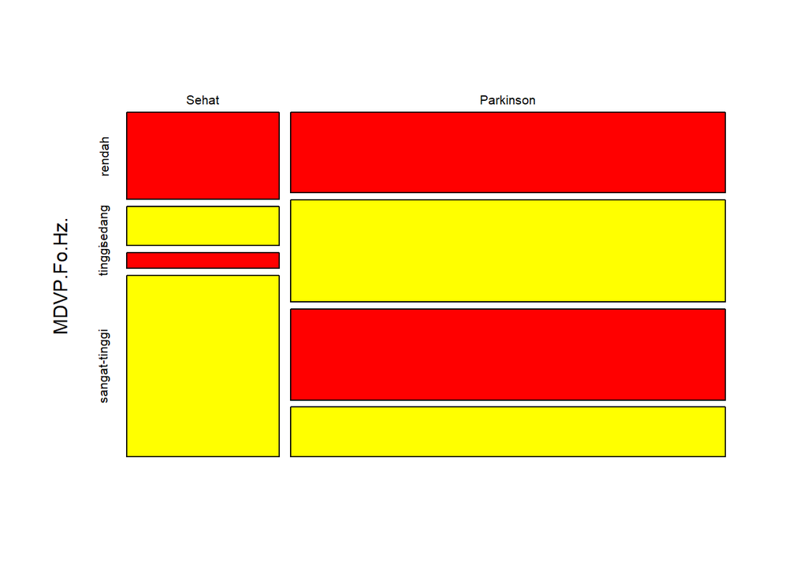

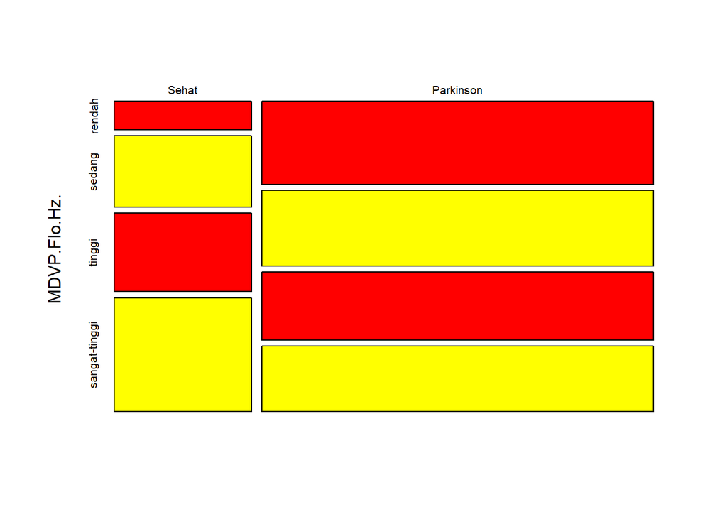

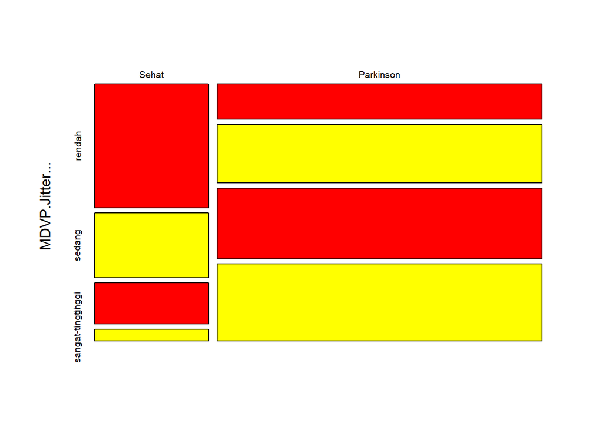

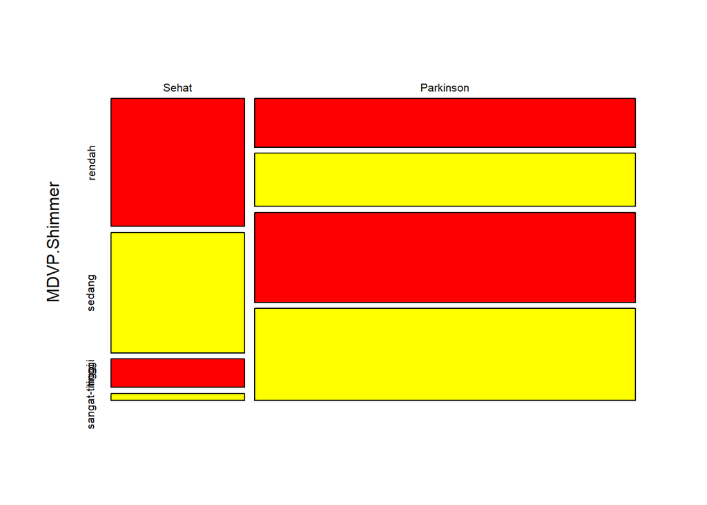

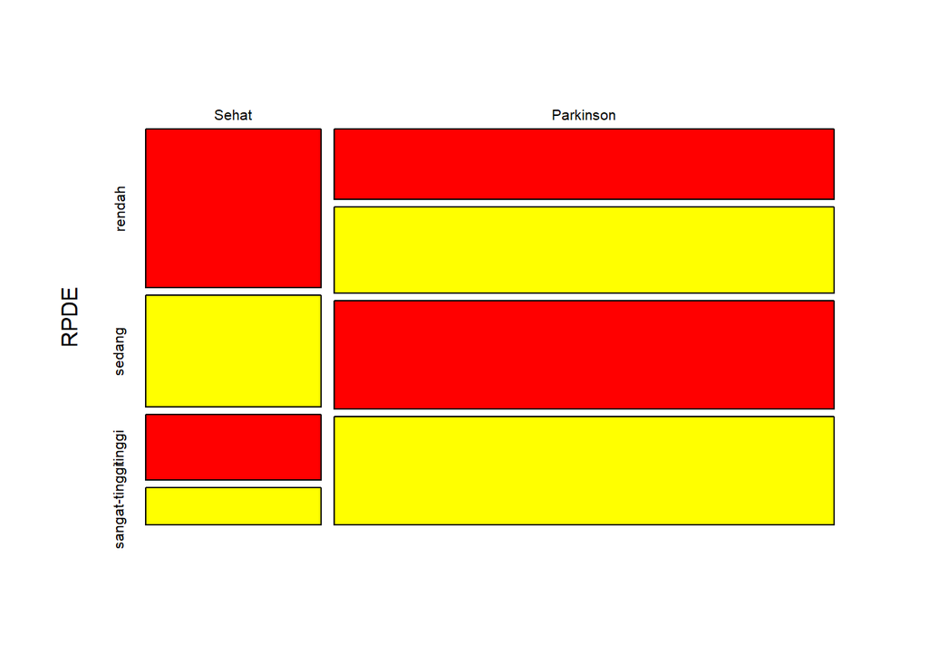

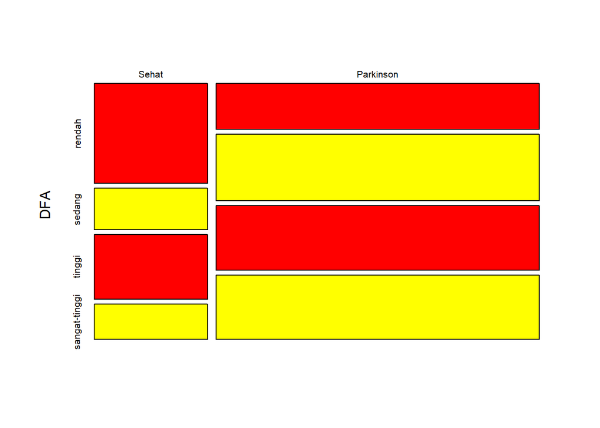

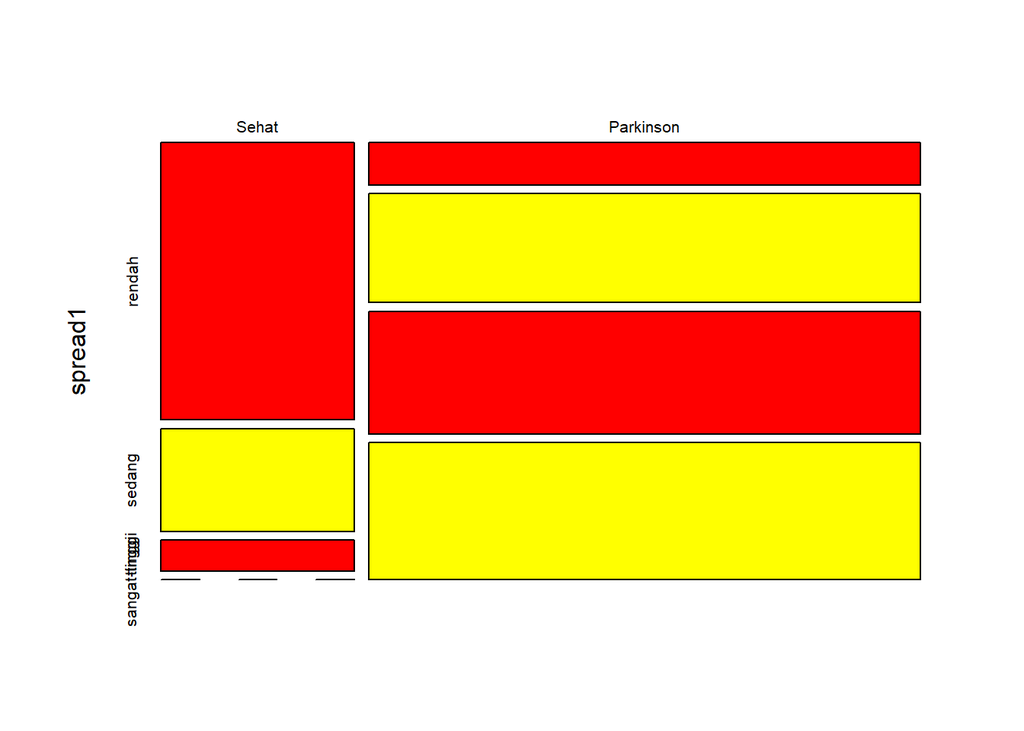

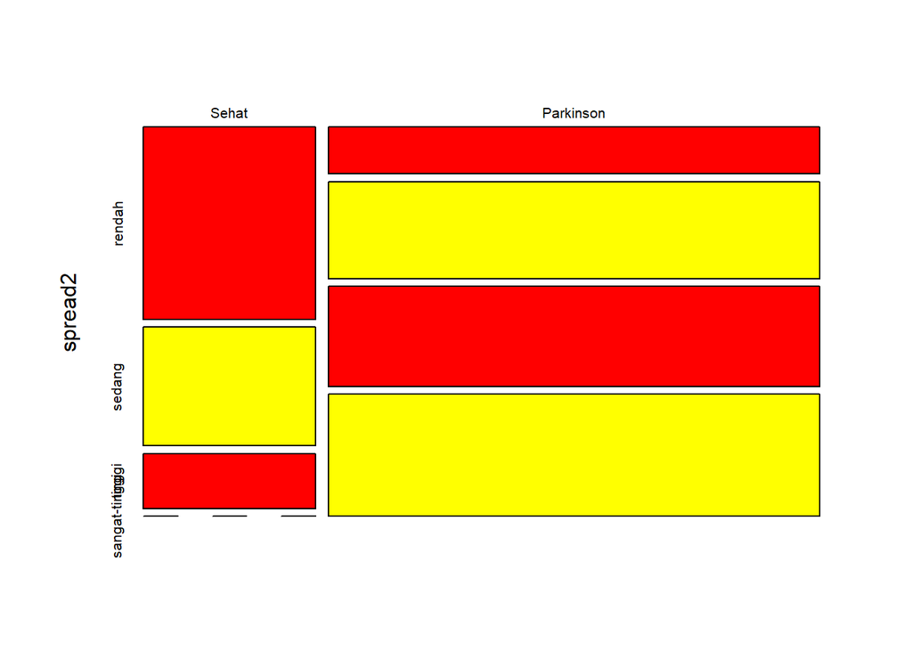

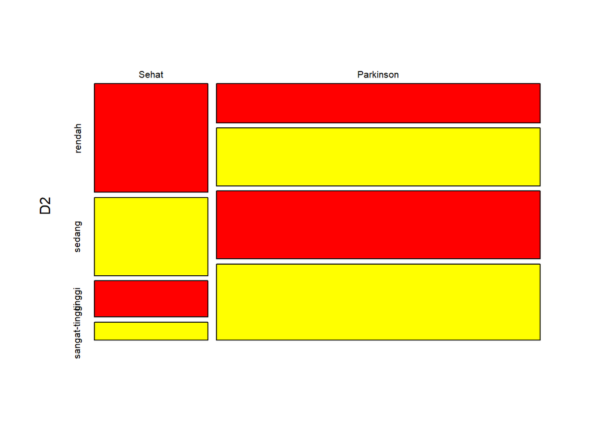

```r
#Visualisasi Model
plot(modelnaiv)
```

# 2. Output

### Summary Model

```r
summary(modelnaiv)
```

```
##
## ================================== Naive Bayes ==================================
##
## - Call: naive_bayes.formula(formula = Status ~ ., data = trainingdat)
## - Laplace: 0
## - Classes: 2
## - Samples: 158
## - Features: 9
## - Conditional distributions:
##     - Categorical: 9
## - Prior probabilities:
##     - Sehat: 0.2595
##     - Parkinson: 0.7405
##
## ---------------------------------------------------------------------------------
```

Interpretasi:

# 3. Confusion Matrix

### Model Validation

*Confusion Matrix*

```r
prediksi <- predict(modelnaiv, testingdat)
confusionMatrix(table(prediksi,testingdat$Status))
```

```
## Confusion Matrix and Statistics
##
##
## prediksi    Sehat Parkinson
##   Sehat         5         6
##   Parkinson     2        24
##
##                Accuracy : 0.7838
##                  95% CI : (0.6179, 0.9017)
##     No Information Rate : 0.8108
##     P-Value [Acc > NIR] : 0.7440
##
##                   Kappa : 0.4219
##
##  Mcnemar's Test P-Value : 0.2888
##
##             Sensitivity : 0.7143
##             Specificity : 0.8000
##          Pos Pred Value : 0.4545
##          Neg Pred Value : 0.9231
##              Prevalence : 0.1892
##          Detection Rate : 0.1351
##    Detection Prevalence : 0.2973
##       Balanced Accuracy : 0.7571
##
##        'Positive' Class : Sehat
##
```

# 4. Evaluasi model

```r
presisi <- 5/(5+2)
recall <- 5/(5+6)
f1 <- 2*(recall*presisi)/(recall+presisi)
```

# 5. Interpretasi statistik

Interpretasi :

- Precission merupakan rasio prediksi benar positif dibandingkan dengan keseluruhan hasil yang diprediksi positf.

Interpretasi

- Spesificity merupakan kebenaran memprediksi negatif dibandingkan dengan keseluruhan data negatif.

Interpretasi :

Persentase pasien yang benar diprediksi menderita parkinson dibandingkan dengan keseluruhan mahasiswa yang sebenarnya menderita parkinson adalah 80%

- Recall menggambarkan keberhasilan model dalam menemukan kembali sebuah informasi. Maka, recall merupakan rasio prediksi benar positif dibandingkan dengan keseluruhan data yang benar positif.

- F1 Score merupakan perbandingan rata-rata presisi dan recall yang dibobotkan

F1 Score = 2 * (Recall*Precission) / (Recall + Precission)